# R programming basics (part 2b)

Author

Prof. Francesca Finotello

# Introduction

In this set of exercises, we will practice core R programming skills, including importing tabular data, applying mathematical transformations, using control structures such as for loops, and creating and customizing a variety of base R plots — including histograms, boxplots, barplots, and scatterplots. We will also explore how to compute summary statistics and combine them with visualizations to better understand data distributions.

# Exercises

## Exercise 1

Let’s load with `read.table` a file named “DE_results.txt” from the “Data” folder, which contains the results of a differential expression (DE) analysis:

```r
DEGs <- read.table("../../Data/DE_results.txt",
                   header = TRUE,
                   sep = "\t")
```

**Warning**

The path “../../Data/DE_results.txt” assumes a specific folder structure. Adjust it to match the location of the “Data” folder on your system.

We can use the same function to import the original count matrix (gene-by-samples) used for differential gene expression analysis, which is called “DE_counts.txt” and is also present in the “Data” directory. Suggestion: specify the option `row.names = 1` to use the information in column number 1 as row names (i.e., the gene names). Try to write the code without looking at the solution below.

**Click to see the solution code**

**Solution:**

```r
counts <- read.table("../../Data/DE_counts.txt",
                     header = TRUE,
                     row.names = 1,
                     sep = "\t")
```

**Warning**

The path “../../Data/DE_counts.txt” assumes a specific folder structure. Adjust it to match the location of the “Data” folder on your system.

The count matrix encompasses 39,374 genes and 4 samples. As summarized in the sample names, the data was generated from blood samples collected from two individuals (“HD30” and “HD31”), before influenza vaccination (day 0) and 7 days after vaccination:

```r
head(counts)
```

```
       HD30_0 HD30_7 HD31_0 HD31_7
COX1   314154 291364 492652 333040
ND4    150671 152858 332675 214387
EEF1A1 149572 176367 235866 182190
LYZ    109469  80074 171779 123590
ACTB   112748 109737 170518 117764
ND5    107624 106738 200857 121691
```

```r
dim(counts)
```

```
[1] 39374     4
```

```r
colnames(counts)
```

```
[1] "HD30_0" "HD30_7" "HD31_0" "HD31_7"
```

Which function(s) can you use to check how many genes are reported instead in the DE result table?

And which function can be used to check which information is reported for every gene (on the columns)?

How many up-regulated and down-regulated genes are reported in the “DE” column (`DEGs$DE`)? *Hint:* use `table`.

## Exercise 2

Let’s check which density distribution have the counts in the “HD30_0” sample. We can use the `hist` function, setting the `freq` parameter to FALSE to plot *probabilities* rather than *frequencies*.

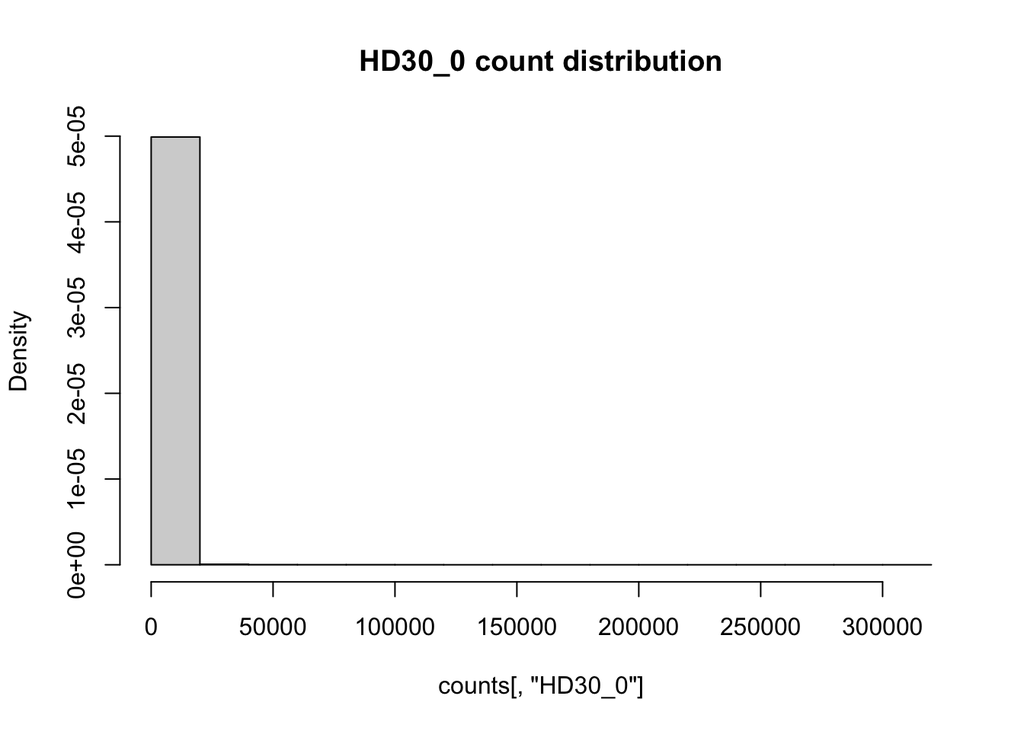

```r
hist(counts[,"HD30_0"],
     main = "HD30_0 count distribution",
     freq = FALSE)
```

The data appear very skewed, with many genes with low and even 0 counts, and a few genes with higher expression. To reduce data skewness, we can perform a logarithmic transformation, adding 1 to avoid $log(0)$:

```r
log_counts <- log(counts+1)
```

We can now plot the histogram of the log-scaled data (`log_counts`); add also a curve using `lines` representing the density distribution computed on the same object using `density`.

**Click to see the solution code**

**Solution:**

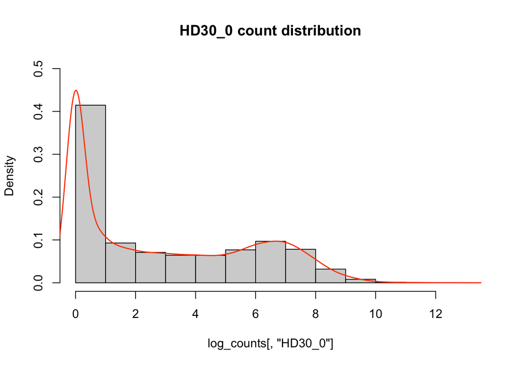

```r
hist(log_counts[,"HD30_0"],
     main = "HD30_0 count distribution",
     ylim = c(0, 0.5),  # let's fix the y-axis between 0 and 0.5
     freq = FALSE)
lines(density(log_counts[,"HD30_0"]),
      col = "orangered",
      lwd = 1.5)
```

## Exercise 3

Let’s make a boxplot of the log-scaled data. The boxplots represent the gene counts (log-scaled) in every sample. We can color them according to the individuals (“HD30” and “HD31”):

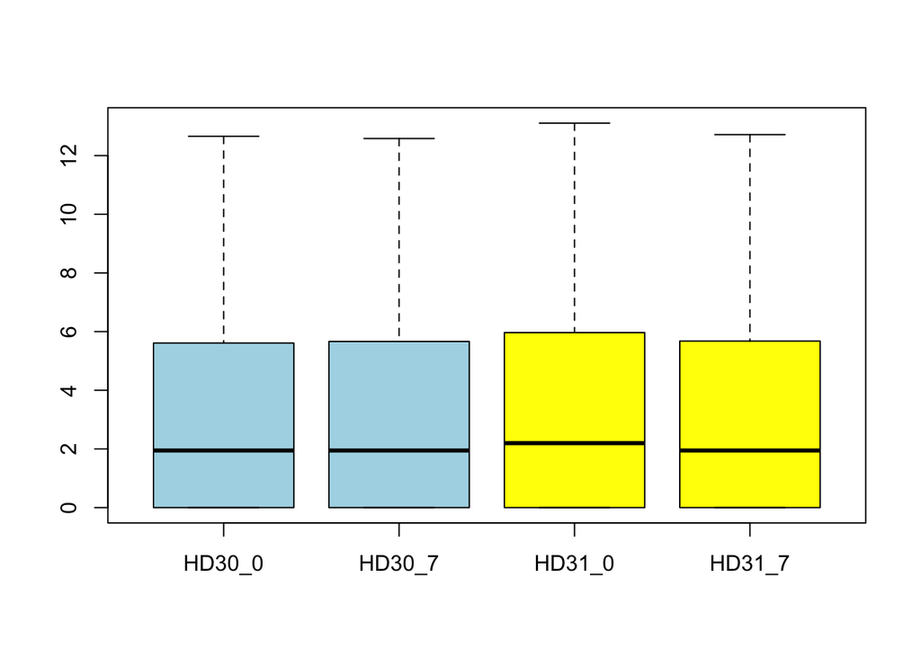

```r
boxplot(log_counts,
        col = c("lightblue", "lightblue", "yellow", "yellow"))
```

Now color them instead according to the days (`0` or `7`) using the following hexadecimal codes as colors, respectively: `#af8dc3` and `#7fbf7b`:

**Click to see the solution code**

**Solution:**

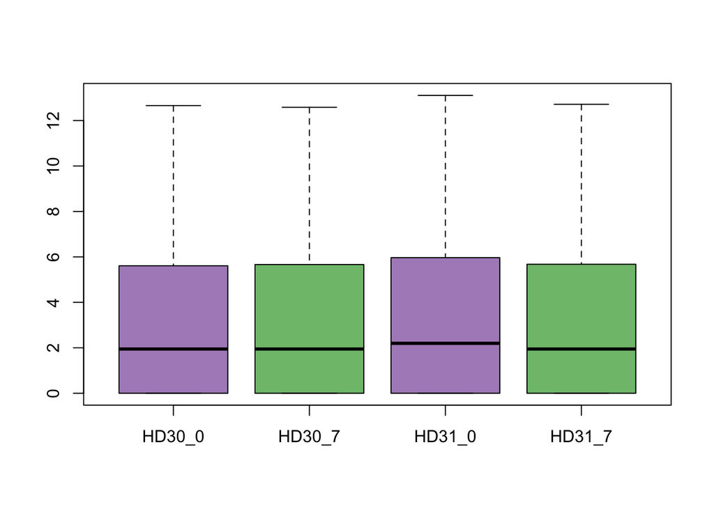

```r
boxplot(log_counts,
        col = c("#af8dc3", "#7fbf7b", "#af8dc3", "#7fbf7b"))
```

## Exercise 4

Let’s compute the **library** size, i.e. the sum of all counts (across all genes) in every sample. Use the original count data, not the log-transformed one. *Hint:* use `apply`.

**Click to see the solution code**

**Solution:**

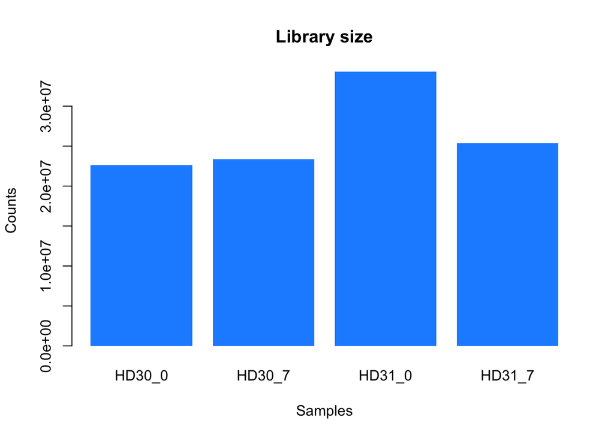

```r
lib_size <- apply(counts, 2, sum)
barplot(lib_size,
        main = "Library size",
        xlab = "Samples",
        ylab = "Counts",
        col = "dodgerblue",
        horiz = FALSE,
        border = NA)
```

Experiment with the arguments above to change the aspect of the plot, and refer to the help section to gather more insights on the parameter settings: `help(barplot)`.

## Exercise 5

Consider again the original count data and write a set of commands to normalize it to counts per millions (CPM). Your commands should:

- Initialize a new `cpm` variable, which originally is equal to the `counts` one.
- Implement a `for` loop that iterates over the columns of `cpm`, i.e., the samples…
- and, for every sample, normalize its values by multiplying it to $10^6$ and dividing it by its library size.

**Click to see the solution code**

**Solution:**

```r
cpm <- counts
for (sample in 1:ncol(cpm)) {
  cpm[, sample] <- cpm[, sample] * 1e6 / lib_size[sample]
}
```

## Exercise 6

Extract the CPM values for the CD8A gene and represent them in the four samples using a barplot. Note that `unlist` is needed to convert the values into a 1-dimensional vector.

**Click to see the solution code**

**Solution:**

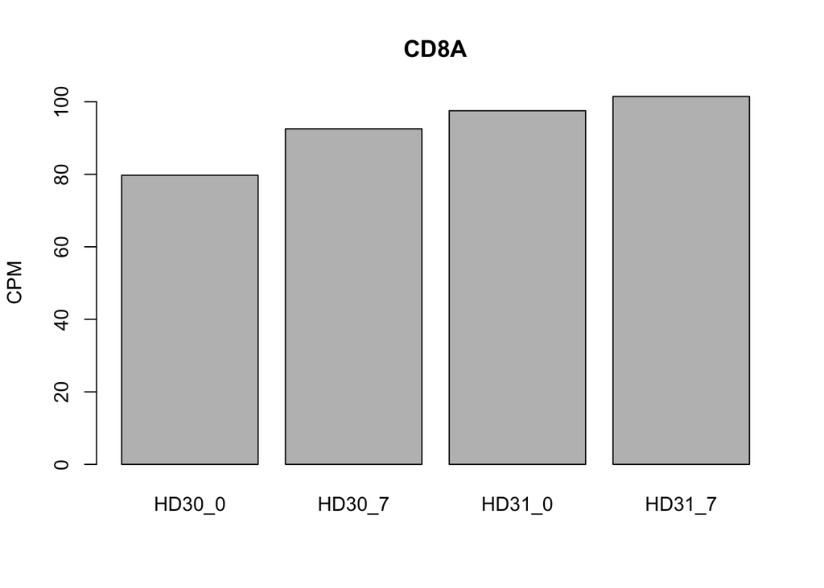

```r
CD8A_cpm <- unlist(cpm["CD8A", ])
barplot(CD8A_cpm,
        ylab = "CPM",
        main = "CD8A")
```

Do the same for the CD8B gene.

Make a scatter plot of the expression of CD8A vs. CD8B genes, in log(CPM+1) format, using the `CD8A_cpm` and `CD8B_cpm` vectors just defined.

**Click to see the solution code**

**Solution:**

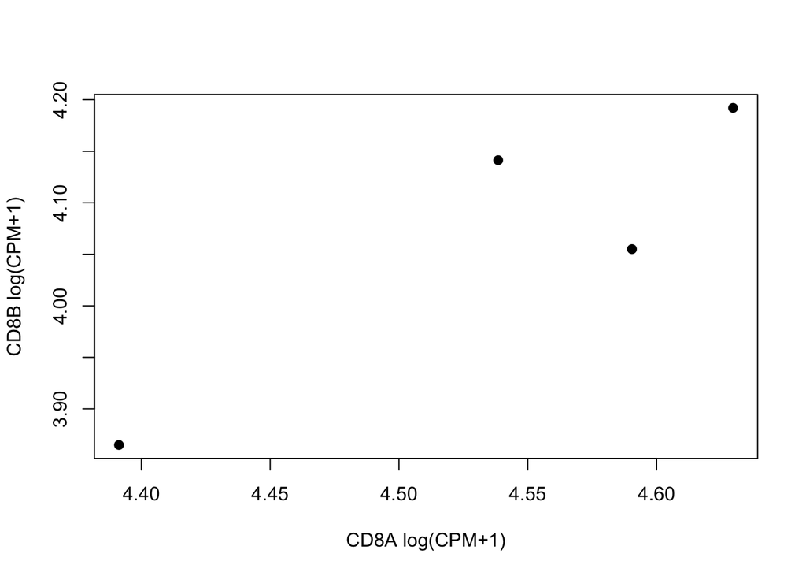

```r
plot(log(CD8A_cpm+1), log(CD8B_cpm+1),
     xlab = "CD8A log(CPM+1)",
     ylab = "CD8B log(CPM+1)",
     pch = 19)
```

## Exercise 7

Compute the log(CPM+1) for all genes and samples from the `cpm` object and save them in a new object called `log_cpm`.

Make a scatterplot for the log-cpm values of samples HD30_7 vs. HD30_0 (i.e., day 7 vs. day 0 data from HD30). Use `abline` to visualize the $y = x$ bisectrix.

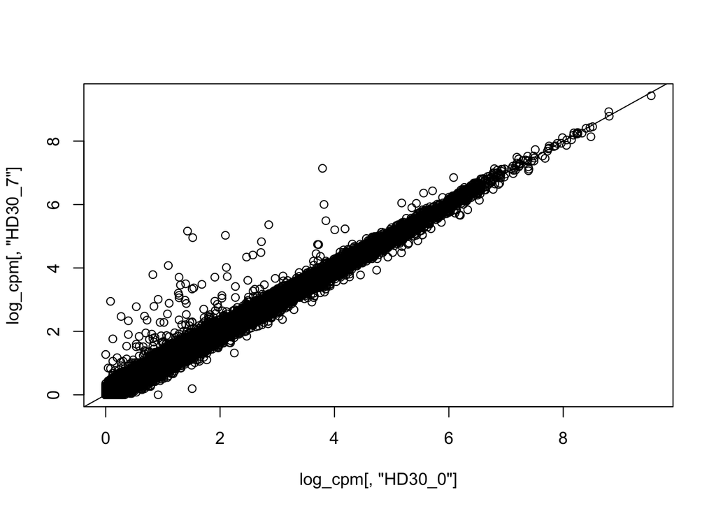

**Click to see the solution code**

**Solution:**

```r
log_cpm <- log(cpm + 1)
plot(log_cpm[, "HD30_0"], log_cpm[, "HD30_7"])
abline(0,1)
```

Compute Pearson’s correlation between the two variables above, round it to 4 decimal values (`round` function), and save it in a variable called `r`. Update the `r` variable to save, rather than the numeric value only, a full string, as shown in the plot below. *Hint*: use `paste` to concatenate the numeric value saved in `r` with the needed additional text. Finally, print this string in the upper-left corner of the plot, as shown below, using the `text` function .

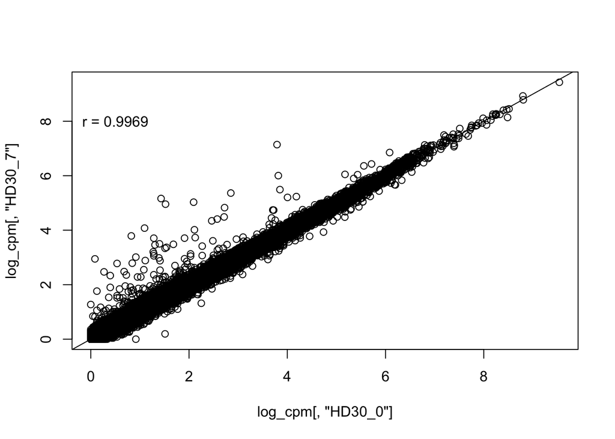

**Click to see the solution code**

**Solution:**

```r
r <- round(cor(log_cpm[, "HD30_0"], log_cpm[, "HD30_7"]),
           digits = 4)
r <- paste("r =", r)
text(0.5, 8, r)
```

Experiment with the plotting parameters (e.g., `lwd`, `cex`, `col`, `xlab`, `ylab`, `main`) to make the plot nicer and more informative

**Click to see the solution code**

**Possible solution:**

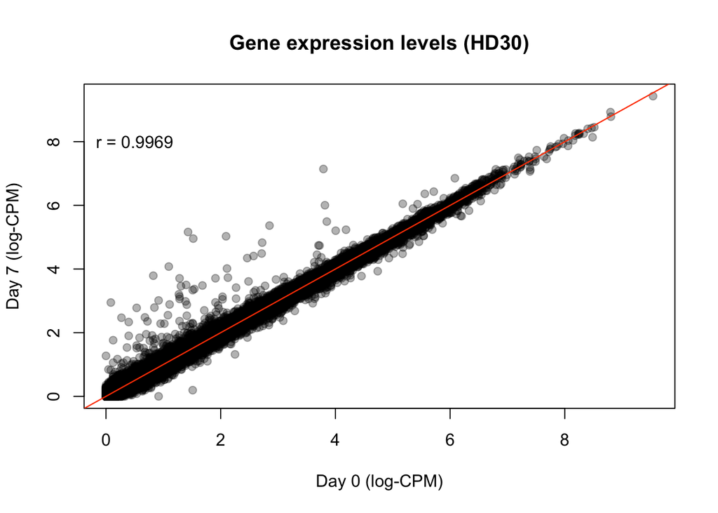

```r
plot(log_cpm[, "HD30_0"],
     log_cpm[, "HD30_7"],
     pch = 19,
     col = rgb(0, 0, 0, 0.3),
    xlab = "Day 0 (log-CPM)",
     ylab = "Day 7 (log-CPM)",
     main = "Gene expression levels (HD30)")
abline(0, 1,
       col = "orangered",
       lwd = 1.2)
text(0.5, 8, r)
```

## Exercise 8

Let’s compare the same samples using an MA-plot instead. For this, we need to define the `M1` and `A1` variables as follows:

```r
M1 <- log_cpm[, "HD30_7"] - log_cpm[, "HD30_0"]
A1 <- ( log_cpm[, "HD30_7"] + log_cpm[, "HD30_0"]) / 2
```

Let’s use the `plot` function to obtain the MA-plot below. *Hint:* `abline(h = 0)` can be used to draw an horizontal line in correspondence of $y = 0$.

**Click to see the solution code**

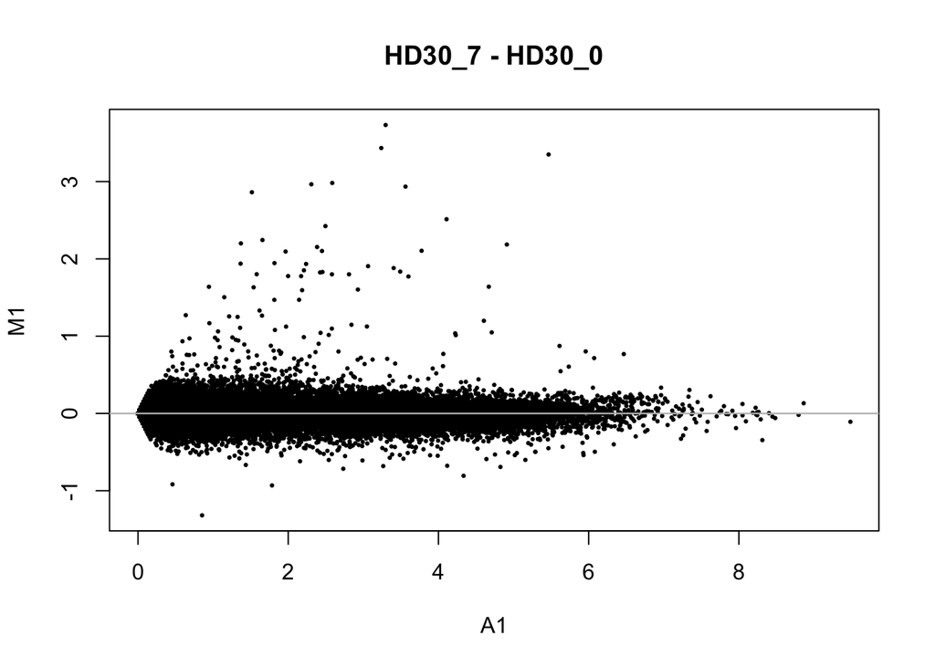

Let’s make the same plot for comparing instead sample HD31_0 vs. HD30_0 (i.e., the day 0/pre-vaccination samples from two individuals)

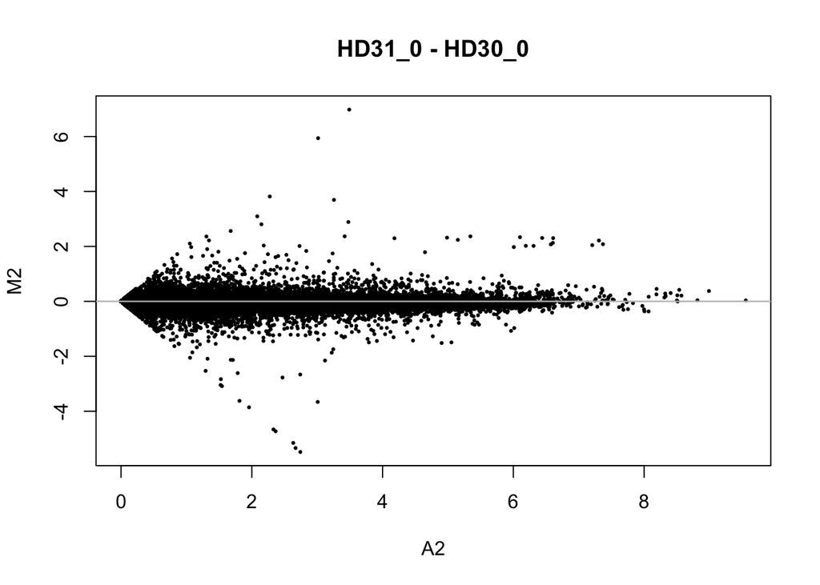

To compare them better, we can fix the plot y-range in [-4,4] (`ylim` parameter) and add two horizontal lines at $y=-1$ and $y=1$ (using `abline`). By doing so, we can see that we have larger differences between different individuals, rather than from different days for individual HD30:

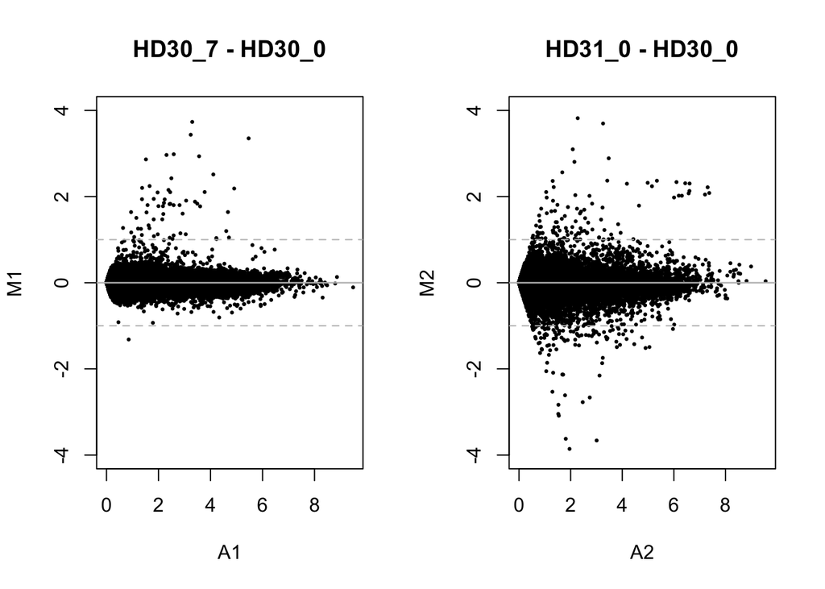

## Exercise 9

Let’s `load` an RDS file named “quartet.RData” from the “Data” folder.

```r
load("../../Data/quartet.RData")
```

**Warning**

The path “../../Data/quartet.RData” assumes a specific folder structure. Adjust it to match the location of the “Data” folder on your system.

This file contains a data.frame with 8 columns and 11 rows, saved in an object called `quartet`.

```r
dim(quartet)
```

```
[1] 11  8
```

```r
head(quartet, 3)
```

```
  x1 x2 x3 x4   y1   y2    y3   y4
1 10 10 10  8 8.04 9.14  7.46 6.58
2  8  8  8  8 6.95 8.14  6.77 5.76
3 13 13 13  8 7.58 8.74 12.74 7.71
```

This data.frame contains 4 pairs of variables: x1-y1, x2-y2, x3-y3, and x4-y4, which represents four different datasets. Let’s compute a few summary statistics on the first dataset, including the mean (rounded to 2 decimals):

```r
round(mean(quartet$x1), 2)
```

```
[1] 9
```

```r
round(mean(quartet$y1), 2)
```

```
[1] 7.5
```

The variance (rounded to 2 decimals):

```r
round(var(quartet$x1), 2)
```

```
[1] 11
```

```r
round(var(quartet$y1), 2)
```

```
[1] 4.13
```

The correlation between x1 and y1 (rounded to 2 decimals):

```r
round(cor(quartet$x1, quartet$y1), 2)
```

```
[1] 0.82
```

And the intercept and slope of the liner fit `lm(y1 ~ x1)` (rounded to 2 decimals):

```r
lfit <- lm(y1 ~ x1, data = quartet)
round(lfit[["coefficients"]][1], 2)
```

```
(Intercept)
          3
```

```r
round(lfit[["coefficients"]][2], 2)
```

```
 x1
0.5
```

Let’s create a matrix to save the summary statistics for all 4 datasets:

```r
stats <- matrix(NA, ncol = 7, nrow = 4)
rownames(stats) <- c("D1", "D2", "D3", "D4")
colnames(stats) <- c("x_mean",
              "y_mean",
              "x_var",
              "y_var",
              "xy_cor",
              "xy_slope",
              "xy_int")
```

We can now save the results for every statistics and dataset in this data.frame, for instance:

```r
stats["D1", "x_mean"] <- round(mean(quartet$x1), 2)
stats["D1", "y_mean"] <- round(mean(quartet$y1), 2)
```

After we do this for all statistics and datasets, the table will look like this:

```r
knitr::kable(stats)
```

[output not shown]

What do you notice? All four datasets have the same statistics. But let’s plot them… are they similar?

**Click to see the solution code**

**Solution:**

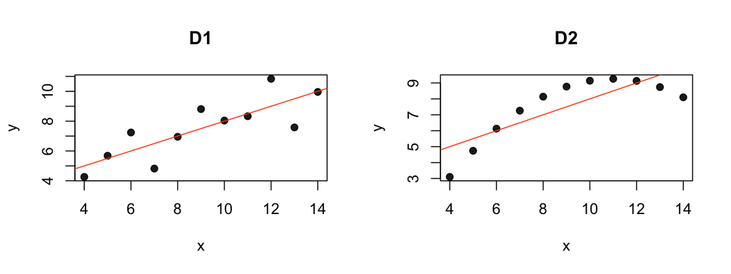

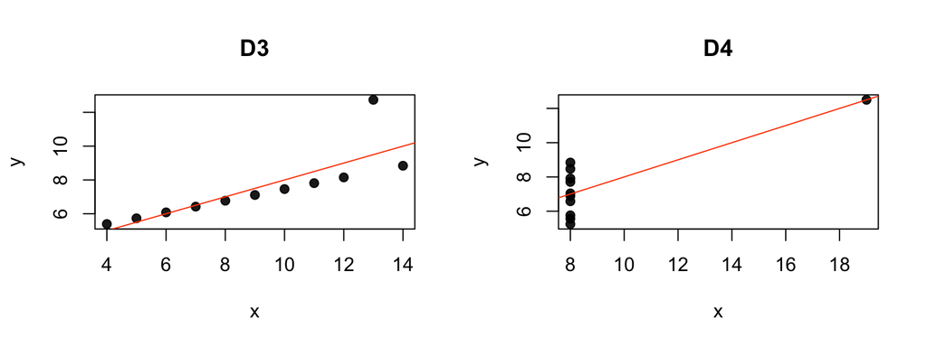

No, they have very different plots.

These four datasets constitute the so-called “Anscombe’s quartet”: they have nearly identical simple descriptive statistics, but very different distributions which become apparent when graphed.

These datasets were constructed in 1973 by the statistician Francis Anscombe to demonstrate both the importance of graphing data when analyzing it, and the effect of outliers on statistical properties (e.g., see D3 and D4 plots).